# Enteric Virus

Lihan Tang

21/06/2020

## Data

Fisrtly, library the packages will be used for the project, such as “dplyr”, “ggplot”, “knitr” and so on.

```r
###Set up
###Load the data and used packages
library(tidyverse)
```

```r
library(readxl)
library(dplyr)
library(tidyr)
library(ggplot2)
library(purrr)
library(knitr)
library(stringr)
library(nnet)
```

Then, load the data and make it as tibble.

```r
file_name <- "Data for enteric virus MSc.xlsx"
Enteric_virus <- read_excel(file_name)
Enteric_virus <- as_tibble(Enteric_virus)
```

For analyzing the data, the preprocessing of the data are conducted.

```r
enteric_virus <- Enteric_virus%>%
  mutate(is_coinf = replace_na(as.numeric(is_coinf),0))%>%
  mutate(if_coinf = purrr::map_lgl(.$is_coinf,~ .>1))%>%
  mutate(if_coinf = as.numeric(if_coinf))%>%
  mutate(is_noinf = purrr::map_lgl(.$is_coinf,~ .==0))%>%
  mutate(is_noinf = as.numeric(is_noinf))%>%
  mutate(is_inf = purrr::map_lgl(.$is_coinf,~ .>0))%>%
  mutate(is_inf = as.numeric(is_inf))%>%
  mutate(is_single = purrr::map_lgl(.$is_coinf,~ .==1))%>%
  mutate(is_single = as.numeric(is_single))%>%
  mutate(Num_common = -(Rotavirus+ Norovirus + Kobuvirus + Sapovirus + Mastadenovirus + Mamastrovirus - 12))%>%
  mutate(is_common = purrr::map_lgl(.$Num_common,~ .>=1))%>%
  mutate(is_common = as.numeric(is_common))%>%
  mutate(is_unclassified = -(`Unclassified virus`-2))%>%
  mutate(Num_uncommon = is_coinf-Num_common
         - `is_unclassified` )%>%
  mutate(is_uncommon = purrr::map_lgl(.$Num_uncommon,~ .>=1))%>%
  mutate(is_uncommon = as.numeric(is_uncommon))%>%
  mutate(is_coinf = as.factor(is_coinf))%>%
  mutate(if_coinf = as.factor(if_coinf))%>%
  mutate(is_noinf = as.factor(is_noinf))%>%
  mutate(is_single = as.factor(is_single))%>%
  mutate(is_inf = as.factor(is_inf))%>%
  mutate(Num_common = as.factor(Num_common))%>%
  mutate(Num_uncommon = as.factor(Num_uncommon))%>%
  mutate(is_unclassified = as.factor(is_unclassified))%>%
  mutate(is_common = as.factor(is_common))%>%
  mutate(is_uncommon = as.factor(is_uncommon))%>%
  mutate(Gender=as.factor(Gender))%>%
  mutate(SiteRecruitment=as.factor(SiteRecruitment))%>%
  mutate(ContactDiar=as.factor(ContactDiar))%>%
  mutate(Tap=as.factor(Tap))%>%
  mutate(Well=as.factor(Well))%>%
  mutate(Rain=as.factor(Rain))%>%
  mutate(River=as.factor(River))%>%
  mutate(Pond=as.factor(Pond))%>%
  mutate(Bottled=as.factor(Bottled))%>%
  mutate(OtherWS=as.factor(OtherWS))%>%
  mutate(KeepAnimal=as.factor(KeepAnimal))%>%
  mutate(KillingAnimal=as.factor(KillingAnimal))%>%
  mutate(EatCookRawMeat=as.factor(EatCookRawMeat))
```

## The distribution of the virus in different areas

Firstly, we are intersted in the number of patients infected with different types of viruses in differnet areas. Therefore, the patients are grouped by the Centrally City. Then, in each area we investigate the number of patients who has no infection of the viruses tested or has single infection or has coinfection. The barplots are shown below.

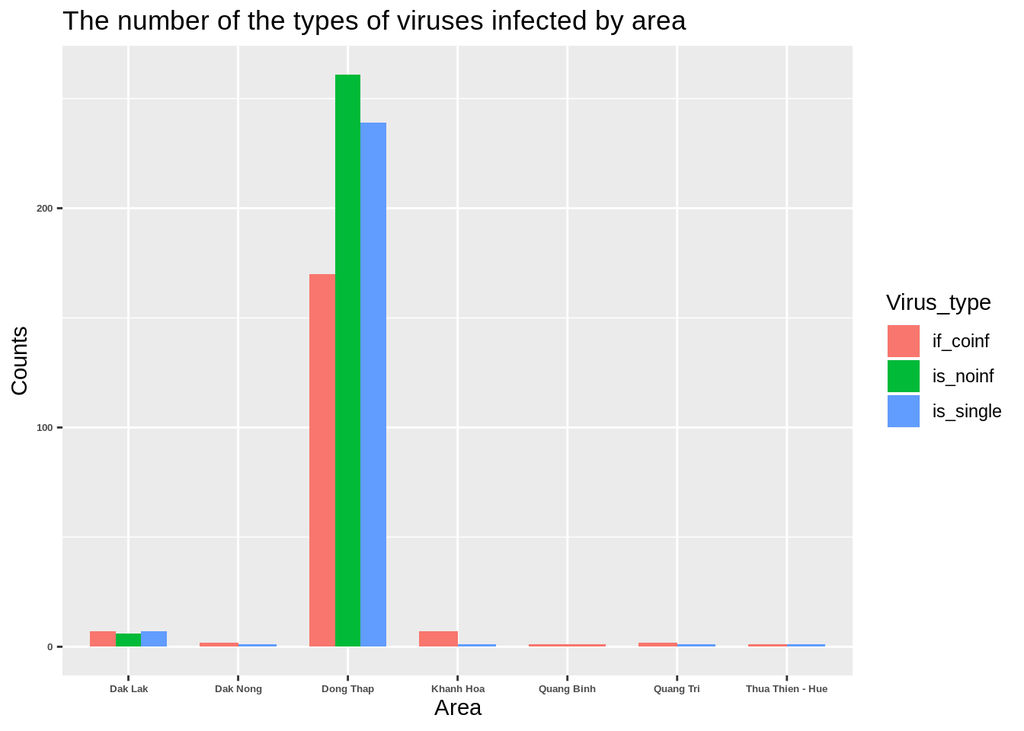

```r
table1 = enteric_virus %>%
  select(`Sample ID`,CentrallyCity,if_coinf,is_single,is_noinf)%>%
  pivot_longer(cols = -c(`Sample ID`,CentrallyCity),names_to = "Infection_type",values_to="is_infected")%>%
  filter(is_infected == 1)%>%
  group_by(CentrallyCity,Infection_type) %>%
  summarise(counts=n()) %>%
  mutate(perc=counts/sum(counts))

ggplot(table1, aes(x=CentrallyCity, y=counts, fill = Infection_type)) +
  geom_bar(stat="identity",position = "dodge",width = 0.7) +
  labs(x = "Area", y = "Counts", fill = "Virus_type",
       title = "The number of the types of viruses infected by area")+
  theme(axis.text=element_text(size=5,face = "bold"))
```

```r
table1%>%
  ungroup()%>%
  group_by(CentrallyCity)%>%
  summarise(total = sum(counts))%>%
  mutate(perc=total/sum(total))
```

```
## # A tibble: 7 x 3
##   CentrallyCity    total    perc
##   <chr>            <int>   <dbl>
## 1 Dak Lak             20 0.0283
## 2 Dak Nong             3 0.00424
## 3 Dong Thap          670 0.948
## 4 Khanh Hoa            8 0.0113
## 5 Quang Binh           1 0.00141
## 6 Quang Tri            3 0.00424
## 7 Thua Thien - Hue     2 0.00283
```

Then, I focus on the patients in Dong Thap city for better analyzing and visualizing the data, since this part of patients accounts for approximately 95% of the dataset. Then, the number of patients who got different types of viruses infected in Dong Thap city are summarised. Note that in this part, for the patients infected with the uncommon viruses, no matter how many different types of viruses the patients are infected, they are only counted once. Also, for the patients who has coinfection of common viruses and uncommon viruses or unclassified viruses, they will be count twice or more times.

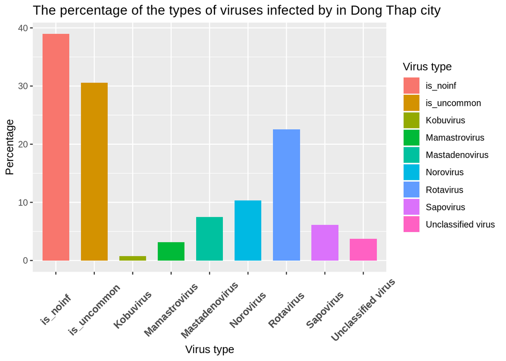

```r
table2 <- enteric_virus %>%
  filter(CentrallyCity == "Dong Thap")%>%
  select(`Sample ID`,Rotavirus,Norovirus,Kobuvirus,Sapovirus, Mastadenovirus,Mamastrovirus,`Unclassified virus`,is_uncommon,is_noinf)%>%
  mutate(is_uncommon = -(as.numeric(is_uncommon)-3))%>%
  mutate(is_noinf = -(as.numeric(is_noinf)-3))%>%
  pivot_longer(cols = -c(`Sample ID`),names_to = "Virus_type",values_to="is_infected")%>%
  filter(is_infected == 1)%>%
  group_by(Virus_type) %>%
  summarise(counts=n())%>%
  mutate(perc= counts/670)

ggplot(table2, aes(x = Virus_type,y=perc*100, fill = Virus_type)) +
  geom_bar(stat="identity",position = "dodge",width = 0.7) +
  labs(x = "Virus type", y = "Percentage", fill = "Virus type",
       title = "The percentage of the types of viruses infected by in Dong Thap city")+
  theme(axis.text.x = element_text(angle = 45, hjust = 0.5, vjust = 0.5,size=10,face = "bold"))
```

From the above plots, the people who are testes for no infection are the most. For the infected patients, 205 patients are infected by the uncommon viruses, followed by 151 patients infected by Rotavirus. For the six common viruses, the patients infected with Rotavirus are the most, while the patients infected with Kobuvirus are the least.

Then for the Dong Thap city, the number of patients who have different infection type in different provincial cities are summarised.

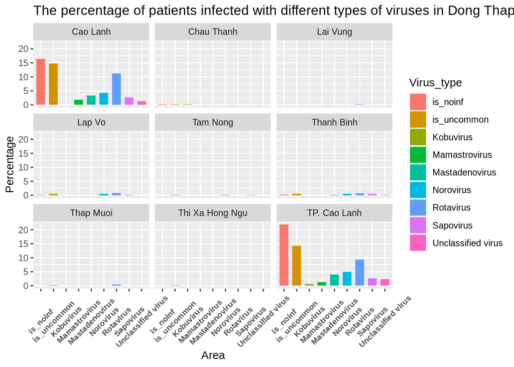

```r
table3 = enteric_virus %>%
  filter(CentrallyCity == "Dong Thap")%>%
  select(`Sample ID`,ProvincialCity,Rotavirus,Norovirus,Kobuvirus,Sapovirus, Mastadenovirus,Mamastrovirus,`Unclassified virus`,is_uncommon,is_noinf)%>%
  mutate(is_uncommon = -(as.numeric(is_uncommon)-3))%>%
  mutate(is_noinf = -(as.numeric(is_noinf)-3))%>%
  pivot_longer(cols = -c(`Sample ID`,ProvincialCity),names_to = "Virus_type",values_to="is_infected")%>%
  filter(is_infected == 1)%>%
  group_by(ProvincialCity,Virus_type) %>%
  summarise(counts=n())%>%
  mutate(perc= counts/670)

ggplot(table3, aes(x = Virus_type,y=perc*100, fill = Virus_type)) +
  geom_bar(stat="identity",position = "dodge",width = 0.7) +
  facet_wrap(vars(ProvincialCity))+
  labs(x = "Area", y = "Percentage", fill = "Virus_type",
       title = "The percentage of patients infected with different types of viruses in Dong Thap city in different area")+
  theme(axis.text.x = element_text(angle = 45, hjust = 0.5, vjust = 0.5,size=8,face = "bold"))
```

From the above plots, the data are most observed in Cao Lanh and TP.Cao Lanh and the distribution of the viruses observed for this two city are similar, which are also resembles that of the Dong Thap city.

What’s more, in Dong Thap city, applroximately 30.6% of the patients are observed to be infected with some uncommon viruses. For the common viruses, 22.5 patients are infected with Rotavirus, while 0.75% patients are infected by Kobuvirus. For the uncommon viruses, only 3.7% patients are infected by unclassified viruses. Therefore, it can be concluded that actually most of the patients are infected by some common pathogens or the pathogens that can be classified.

## The distribution of the combination of the coinfection in different areas

For this dataset, we are more interested in the coinfection. Therefore, the combinations of the coinfections are investigated. Firstly, the combination of the coinfection or the type of single infection are summarised.

```r
coinf_table <- Enteric_virus%>%
  mutate(is_coinf = replace_na(as.numeric(is_coinf),0))%>%
  mutate(if_coinf = purrr::map_lgl(.$is_coinf,~ .>1))%>%
  mutate(if_coinf = as.numeric(if_coinf))%>%
  mutate(is_noinf = purrr::map_lgl(.$is_coinf,~ .==0))%>%
  mutate(is_noinf = as.numeric(is_noinf))%>%
  mutate(is_inf = purrr::map_lgl(.$is_coinf,~ .>0))%>%
  mutate(is_inf = as.numeric(is_inf))%>%
  mutate(is_single = purrr::map_lgl(.$is_coinf,~ .==1))%>%
  mutate(is_single = as.numeric(is_single))%>%
  mutate(Num_common = -(Rotavirus+ Norovirus + Kobuvirus + Sapovirus + Mastadenovirus + Mamastrovirus - 12))%>%
  mutate(is_common = purrr::map_lgl(.$Num_common,~ .>=1))%>%
  mutate(is_common = as.numeric(is_common))%>%
  mutate(is_unclassified = -(`Unclassified virus`-2))%>%
  mutate(Num_uncommon = is_coinf-Num_common
         - `is_unclassified` )%>%
  mutate(is_uncommon = purrr::map_lgl(.$Num_uncommon,~ .>=1))%>%
  mutate(is_uncommon = as.numeric(is_uncommon))%>%
  filter(is_coinf >0)

n<- length(coinf_table$is_coinf)
sin_common<- numeric(n)
sin_uncommon<- numeric(n)
sin_unclassified<- numeric(n)
co_allcommon<- numeric(n)
co_alluncommon<- numeric(n)
co_allunclassified<- numeric(n)
co_com_uncom<- numeric(n)
co_com_unclassified<- numeric(n)
co_uncom_unclassified<- numeric(n)
co_alltypes<- numeric(n)


for(i in 1:n){
  if(coinf_table$is_single[i] ==1){
    if(coinf_table$is_common[i] == 1){
      sin_common[i]<- 1
    }else if(coinf_table$is_uncommon[i] == 1){
      sin_uncommon[i]<-1
    }else{
      sin_unclassified[i]<-1
    }
  }else{
    if(coinf_table$is_common[i] ==1){
      if(coinf_table$is_uncommon[i] ==1){
        if(coinf_table$is_unclassified[i]==1){
          co_alltypes[i]<-1
        }else{
          co_com_uncom[i]<-1
        }
      }else if(coinf_table$is_unclassified[i] ==1){
        co_com_unclassified[i]<-1
      }else{
        co_allcommon[i]<-1
      }
    }else if(coinf_table$is_uncommon[i] ==1){
      if(coinf_table$is_unclassified[i] == 1){
        co_uncom_unclassified[i]<-1
      }else{
        co_alluncommon[i]<-1
      }
    }else{
      co_allunclassified[i]<-1
    }
  }
}



coinf_table <- coinf_table %>%
  filter(is_coinf > 0)%>%
  mutate(sin_common = sin_common)%>%
  mutate(sin_uncommon = sin_uncommon)%>%
  mutate(sin_unclassified = sin_unclassified)%>%
  mutate(co_allcommon = co_allcommon)%>%
  mutate(co_allunclassified = co_allunclassified)%>%
  mutate(co_alluncommon = co_alluncommon)%>%
  mutate(co_com_uncom = co_com_uncom)%>%
  mutate(co_com_unclassified = co_com_unclassified)%>%
  mutate(co_uncom_unclassifiedc= co_uncom_unclassified)%>%
  mutate(co_alltypes=co_alltypes)
```

Then, the distribution of the combination of the coinfection are examined.

```r
coinf_table1 <- coinf_table%>%
  select(`Sample ID`,sin_common,sin_unclassified,sin_uncommon,co_allcommon,co_allunclassified,co_alluncommon,co_com_unclassified,co_com_uncom,co_uncom_unclassified,co_alltypes)%>%
  pivot_longer(cols = -c(`Sample ID`),names_to = "Combination_type",values_to="is_combi")%>%
  filter(is_combi == 1)%>%
  group_by(Combination_type) %>%
  summarise(counts=n())%>%
  mutate(perc = counts/sum(counts))
```

```
## Note: Using an external vector in selections is ambiguous.
## ℹ Use `all_of(co_uncom_unclassified)` instead of `co_uncom_unclassified` to silence this message.
## ℹ See <https://tidyselect.r-lib.org/reference/faq-external-vector.html>.
```

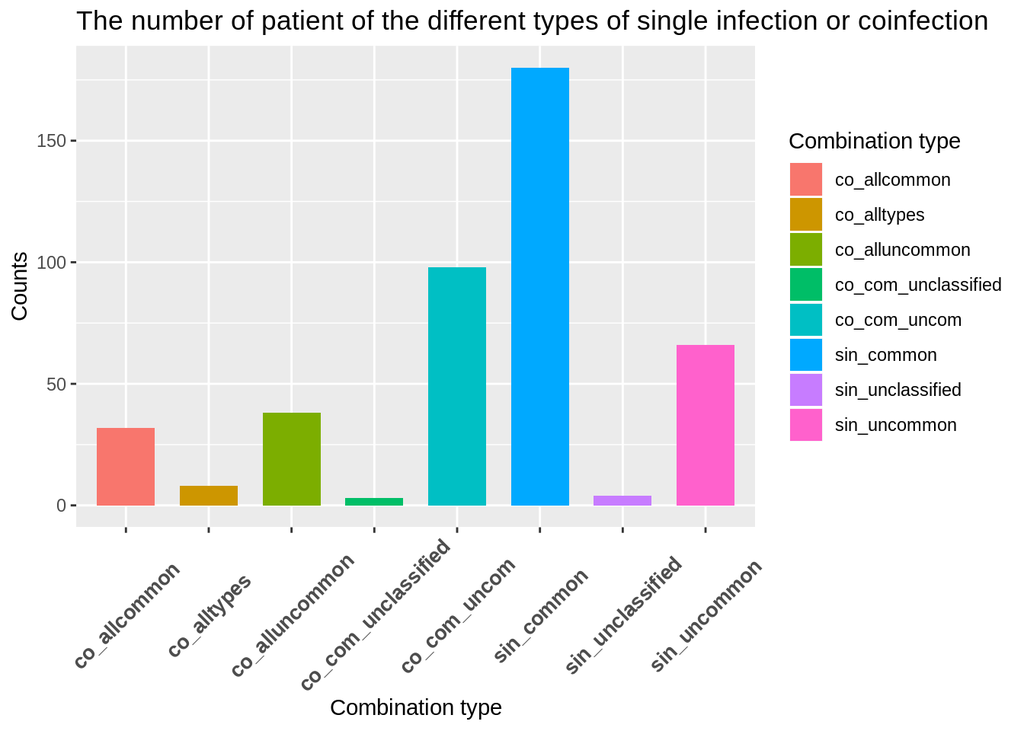

```r
ggplot(coinf_table1, aes(x = Combination_type,y=counts, fill = Combination_type)) +
  geom_bar(stat="identity",position = "dodge",width = 0.7) +
  labs(x = "Combination type", y = "Counts", fill = "Combination type",
       title = "The number of patient of the different types of single infection or coinfection")+
  theme(axis.text.x = element_text(angle = 45, hjust = 0.5, vjust = 0.5,size=10,face = "bold"))
```

Therefore, we can conclude that, most people are actually single infected with some common virus. And for the coinfection patients, most patients are observed with combinations with some common pathogens.

## The risk factors corresponding to the coinfection

Firstly, choose the possible useful variables and form a new table to fit the models.

```r
table_riskfactor <- enteric_virus%>%
  select(Sample_ID = "Sample ID",
         Age = "Age",
         Year_of_enrollment="Year of enrollment",
         SiteRecruitment="SiteRecruitment",
         Gender="Gender",
         ContactDiar ="ContactDiar",
         Tap="Tap",Well="Well",
         Rain = "Rain",
         River = "River",
         Pond = "Pond",
         Bottled = "Bottled",
         OtherWS = "OtherWS",
         KeepAnimal = "KeepAnimal",
         KillingAnimal = "KillingAnimal",
         EatCookRawMeat = "EatCookRawMeat",
         is_coinf ="is_coinf",
         if_coinf ="if_coinf",
         Num_common = "Num_common",
         Num_uncommon ="Num_uncommon"
         )
```

### Multinomial Logit Model

#### The binary reponse for the coinfection

Firstly, the binomial logit for if there is the coinfection is fitted. Since the response variable is the binary data, the “glm” function is used to fit the logit model.

```r
bin_model <-
  glm(
    if_coinf ~ Age + Year_of_enrollment + SiteRecruitment + Gender + ContactDiar + Tap + Well + Rain + River + Pond + Bottled + KeepAnimal + KillingAnimal + EatCookRawMeat,
    family = binomial(link = logit),
    table_riskfactor
  )

summary(bin_model)
```

```
##
## Call:
## glm(formula = if_coinf ~ Age + Year_of_enrollment + SiteRecruitment +
##     Gender + ContactDiar + Tap + Well + Rain + River + Pond +
##     Bottled + KeepAnimal + KillingAnimal + EatCookRawMeat, family = binomial(link = logit),
##     data = table_riskfactor)
##
## Deviance Residuals:
##     Min       1Q   Median       3Q      Max
## -2.1740  -0.8546  -0.6471   0.9794   2.3307
##
## Coefficients:
##                      Estimate Std. Error z value Pr(>|z|)
## (Intercept)        295.391216 249.006327   1.186   0.2355
## Age                 -0.022293   0.004396  -5.072 3.94e-07 ***
## Year_of_enrollment  -0.147328   0.123691  -1.191   0.2336
## SiteRecruitment4     0.105253   0.750369   0.140   0.8884
## SiteRecruitment5     1.702387   1.134504   1.501   0.1335
## SiteRecruitment6     3.178329   1.321983   2.404   0.0162 *
## Gender2              0.033050   0.183226   0.180   0.8569
## ContactDiar2        -0.182713   0.529031  -0.345   0.7298
## ContactDiar9        -0.481238   0.937236  -0.513   0.6076
## TapTRUE              0.113408   0.597927   0.190   0.8496
## WellTRUE             1.316952   0.899520   1.464   0.1432
## RainTRUE             0.121675   0.814510   0.149   0.8813
## RiverTRUE            0.136688   0.613887   0.223   0.8238
## PondTRUE             0.296171   1.347025   0.220   0.8260
## BottledTRUE         -0.002805   0.594098  -0.005   0.9962
## KeepAnimal2          0.038823   0.186532   0.208   0.8351
## KillingAnimal2       0.575605   0.777520   0.740   0.4591
## EatCookRawMeat2     -0.222038   0.229414  -0.968   0.3331
## ---
## Signif. codes:  0 '***' 0.001 '**' 0.01 '*' 0.05 '.' 0.1 ' ' 1
##
## (Dispersion parameter for binomial family taken to be 1)
##
##     Null deviance: 822.95  on 706  degrees of freedom
## Residual deviance: 762.90  on 689  degrees of freedom
## AIC: 798.9
##
## Number of Fisher Scoring iterations: 4
```

From above model, only the age and Site recruiment 6 is very significant. Therefore,using the Chi-test to drop some variables.

```r
drop1(bin_model, test ="Chi")
```

```
## Single term deletions
##
## Model:
## if_coinf ~ Age + Year_of_enrollment + SiteRecruitment + Gender +
##     ContactDiar + Tap + Well + Rain + River + Pond + Bottled +
##     KeepAnimal + KillingAnimal + EatCookRawMeat
##                    Df Deviance    AIC    LRT  Pr(>Chi)
## <none>                  762.90 798.90
## Age                 1   794.84 828.84 31.934 1.595e-08 ***
## Year_of_enrollment  1   764.33 798.33  1.428  0.232150
## SiteRecruitment     3   777.43 807.43 14.528  0.002268 **
## Gender              1   762.94 796.94  0.033  0.856847
## ContactDiar         2   763.18 795.18  0.273  0.872434
## Tap                 1   762.94 796.94  0.036  0.850435
## Well                1   765.10 799.10  2.197  0.138319
## Rain                1   762.92 796.92  0.022  0.881705
## River               1   762.95 796.95  0.049  0.824973
## Pond                1   762.95 796.95  0.047  0.828065
## Bottled             1   762.90 796.90  0.000  0.996233
## KeepAnimal          1   762.95 796.95  0.043  0.835173
## KillingAnimal       1   763.50 797.50  0.596  0.439971
## EatCookRawMeat      1   763.85 797.85  0.948  0.330151
## ---
## Signif. codes:  0 '***' 0.001 '**' 0.01 '*' 0.05 '.' 0.1 ' ' 1
```

```r
bin_model1 <-   glm(
    if_coinf ~ Age + Year_of_enrollment + SiteRecruitment + Gender + ContactDiar + Tap + Well + Rain + River + Pond + KeepAnimal + KillingAnimal + EatCookRawMeat,
    family = binomial(link = logit),
    table_riskfactor
  )

summary(bin_model1)
```

```
##
## Call:
## glm(formula = if_coinf ~ Age + Year_of_enrollment + SiteRecruitment +
##     Gender + ContactDiar + Tap + Well + Rain + River + Pond +
##     KeepAnimal + KillingAnimal + EatCookRawMeat, family = binomial(link = logit),
##     data = table_riskfactor)
##
## Deviance Residuals:
##     Min       1Q   Median       3Q      Max
## -2.1740  -0.8546  -0.6471   0.9795   2.3307
##
## Coefficients:
##                      Estimate Std. Error z value Pr(>|z|)
## (Intercept)        295.471830 248.415580   1.189   0.2343
## Age                 -0.022294   0.004394  -5.074 3.89e-07 ***
## Year_of_enrollment  -0.147370   0.123376  -1.194   0.2323
## SiteRecruitment4     0.105506   0.748482   0.141   0.8879
## SiteRecruitment5     1.702678   1.132828   1.503   0.1328
## SiteRecruitment6     3.178585   1.320920   2.406   0.0161 *
## Gender2              0.033035   0.183199   0.180   0.8569
## ContactDiar2        -0.182737   0.529004  -0.345   0.7298
## ContactDiar9        -0.481367   0.936868  -0.514   0.6074
## TapTRUE              0.116024   0.224608   0.517   0.6055
## WellTRUE             1.319338   0.744091   1.773   0.0762 .
## RainTRUE             0.124080   0.635594   0.195   0.8452
## RiverTRUE            0.139318   0.257954   0.540   0.5891
## PondTRUE             0.298176   1.278373   0.233   0.8156
## KeepAnimal2          0.038766   0.186146   0.208   0.8350
## KillingAnimal2       0.575627   0.777528   0.740   0.4591
## EatCookRawMeat2     -0.222018   0.229377  -0.968   0.3331
## ---
## Signif. codes:  0 '***' 0.001 '**' 0.01 '*' 0.05 '.' 0.1 ' ' 1
##
## (Dispersion parameter for binomial family taken to be 1)
##
##     Null deviance: 822.95  on 706  degrees of freedom
## Residual deviance: 762.90  on 690  degrees of freedom
## AIC: 796.9
##
## Number of Fisher Scoring iterations: 4
```

```r
drop1(bin_model1, test ="Chi")
```

```
## Single term deletions
##
## Model:
## if_coinf ~ Age + Year_of_enrollment + SiteRecruitment + Gender +
##     ContactDiar + Tap + Well + Rain + River + Pond + KeepAnimal +
##     KillingAnimal + EatCookRawMeat
##                    Df Deviance    AIC    LRT  Pr(>Chi)
## <none>                  762.90 796.90
## Age                 1   794.87 826.87 31.967 1.568e-08 ***
## Year_of_enrollment  1   764.34 796.34  1.437  0.230651
## SiteRecruitment     3   777.43 805.43 14.528  0.002267 **
## Gender              1   762.94 794.94  0.033  0.856890
## ContactDiar         2   763.18 793.18  0.273  0.872299
## Tap                 1   763.17 795.17  0.268  0.604556
## Well                1   766.35 798.35  3.446  0.063397 .
## Rain                1   762.94 794.94  0.038  0.846211
## River               1   763.19 795.19  0.292  0.589104
## Pond                1   762.96 794.96  0.053  0.818334
## KeepAnimal          1   762.95 794.95  0.043  0.835075
## KillingAnimal       1   763.50 795.50  0.596  0.439962
## EatCookRawMeat      1   763.85 795.85  0.948  0.330115
## ---
## Signif. codes:  0 '***' 0.001 '**' 0.01 '*' 0.05 '.' 0.1 ' ' 1
```

```r
bin_model2 <-   glm(
    if_coinf ~ Age + Year_of_enrollment + SiteRecruitment + Gender + Tap + Well + Rain + River + Pond + KeepAnimal + KillingAnimal + EatCookRawMeat,
    family = binomial(link = logit),
    table_riskfactor
  )

summary(bin_model2)
```

```
##
## Call:
## glm(formula = if_coinf ~ Age + Year_of_enrollment + SiteRecruitment +
##     Gender + Tap + Well + Rain + River + Pond + KeepAnimal +
##     KillingAnimal + EatCookRawMeat, family = binomial(link = logit),
##     data = table_riskfactor)
##
## Deviance Residuals:
##     Min       1Q   Median       3Q      Max
## -2.1475  -0.8563  -0.6442   0.9765   2.3340
##
## Coefficients:
##                      Estimate Std. Error z value Pr(>|z|)
## (Intercept)        290.902214 247.216657   1.177   0.2393
## Age                 -0.022439   0.004385  -5.117 3.11e-07 ***
## Year_of_enrollment  -0.145239   0.122779  -1.183   0.2368
## SiteRecruitment4     0.135120   0.747575   0.181   0.8566
## SiteRecruitment5     1.730859   1.133008   1.528   0.1266
## SiteRecruitment6     3.138783   1.309553   2.397   0.0165 *
## Gender2              0.035498   0.183083   0.194   0.8463
## TapTRUE              0.114196   0.224575   0.509   0.6111
## WellTRUE             1.321242   0.741787   1.781   0.0749 .
## RainTRUE             0.122700   0.634953   0.193   0.8468
## RiverTRUE            0.138859   0.257907   0.538   0.5903
## PondTRUE             0.226866   1.270775   0.179   0.8583
## KeepAnimal2          0.041438   0.185923   0.223   0.8236
## KillingAnimal2       0.644374   0.765947   0.841   0.4002
## EatCookRawMeat2     -0.219842   0.228972  -0.960   0.3370
## ---
## Signif. codes:  0 '***' 0.001 '**' 0.01 '*' 0.05 '.' 0.1 ' ' 1
##
## (Dispersion parameter for binomial family taken to be 1)
##
##     Null deviance: 822.95  on 706  degrees of freedom
## Residual deviance: 763.18  on 692  degrees of freedom
## AIC: 793.18
##
## Number of Fisher Scoring iterations: 4
```

```r
drop1(bin_model2, test ="Chi")
```

```
## Single term deletions
##
## Model:
## if_coinf ~ Age + Year_of_enrollment + SiteRecruitment + Gender +
##     Tap + Well + Rain + River + Pond + KeepAnimal + KillingAnimal +
##     EatCookRawMeat
##                    Df Deviance    AIC    LRT  Pr(>Chi)
## <none>                  763.18 793.18
## Age                 1   795.80 823.80 32.625 1.118e-08 ***
## Year_of_enrollment  1   764.58 792.58  1.408  0.235321
## SiteRecruitment     3   777.51 801.51 14.331  0.002487 **
## Gender              1   763.21 791.21  0.038  0.846251
## Tap                 1   763.44 791.44  0.260  0.610222
## Well                1   766.65 794.65  3.476  0.062258 .
## Rain                1   763.21 791.21  0.037  0.847739
## River               1   763.47 791.47  0.290  0.590263
## Pond                1   763.21 791.21  0.031  0.859967
## KeepAnimal          1   763.23 791.23  0.050  0.823682
## KillingAnimal       1   763.95 791.95  0.778  0.377828
## EatCookRawMeat      1   764.11 792.11  0.933  0.334063
## ---
## Signif. codes:  0 '***' 0.001 '**' 0.01 '*' 0.05 '.' 0.1 ' ' 1
```

```r
bin_model3 <-   glm(
    if_coinf ~ Age + Year_of_enrollment + SiteRecruitment + Gender + Tap + Well + Rain + River  + KeepAnimal + KillingAnimal + EatCookRawMeat,
    family = binomial(link = logit),
    table_riskfactor
  )

summary(bin_model3)
```

```
##
## Call:
## glm(formula = if_coinf ~ Age + Year_of_enrollment + SiteRecruitment +
##     Gender + Tap + Well + Rain + River + KeepAnimal + KillingAnimal +
##     EatCookRawMeat, family = binomial(link = logit), data = table_riskfactor)
##
## Deviance Residuals:
##     Min       1Q   Median       3Q      Max
## -2.1453  -0.8566  -0.6472   0.9747   2.3350
##
## Coefficients:
##                      Estimate Std. Error z value Pr(>|z|)
## (Intercept)        292.564446 247.032338   1.184   0.2363
## Age                 -0.022452   0.004384  -5.121 3.03e-07 ***
## Year_of_enrollment  -0.146049   0.122691  -1.190   0.2339
## SiteRecruitment4     0.131033   0.746876   0.175   0.8607
## SiteRecruitment5     1.728172   1.132845   1.526   0.1271
## SiteRecruitment6     3.129941   1.307813   2.393   0.0167 *
## Gender2              0.036443   0.183005   0.199   0.8422
## TapTRUE              0.111106   0.223832   0.496   0.6196
## WellTRUE             1.322953   0.741649   1.784   0.0745 .
## RainTRUE             0.119605   0.634774   0.188   0.8505
## RiverTRUE            0.135569   0.257180   0.527   0.5981
## KeepAnimal2          0.041472   0.185930   0.223   0.8235
## KillingAnimal2       0.621177   0.751845   0.826   0.4087
## EatCookRawMeat2     -0.222111   0.228623  -0.972   0.3313
## ---
## Signif. codes:  0 '***' 0.001 '**' 0.01 '*' 0.05 '.' 0.1 ' ' 1
##
## (Dispersion parameter for binomial family taken to be 1)
##
##     Null deviance: 822.95  on 706  degrees of freedom
## Residual deviance: 763.21  on 693  degrees of freedom
## AIC: 791.21
##
## Number of Fisher Scoring iterations: 4
```

```r
drop1(bin_model3, test ="Chi")
```

```
## Single term deletions
##
## Model:
## if_coinf ~ Age + Year_of_enrollment + SiteRecruitment + Gender +
##     Tap + Well + Rain + River + KeepAnimal + KillingAnimal +
##     EatCookRawMeat
##                    Df Deviance    AIC    LRT  Pr(>Chi)
## <none>                  763.21 791.21
## Age                 1   795.90 821.90 32.695 1.078e-08 ***
## Year_of_enrollment  1   764.63 790.63  1.426  0.232365
## SiteRecruitment     3   777.52 799.52 14.310  0.002513 **
## Gender              1   763.25 789.25  0.040  0.842145
## Tap                 1   763.45 789.45  0.248  0.618795
## Well                1   766.70 792.70  3.488  0.061816 .
## Rain                1   763.24 789.24  0.035  0.851470
## River               1   763.49 789.49  0.278  0.598083
## KeepAnimal          1   763.26 789.26  0.050  0.823547
## KillingAnimal       1   763.95 789.95  0.747  0.387321
## EatCookRawMeat      1   764.16 790.16  0.956  0.328314
## ---
## Signif. codes:  0 '***' 0.001 '**' 0.01 '*' 0.05 '.' 0.1 ' ' 1
```

```r
bin_model4 <-   glm(
    if_coinf ~ Age + Year_of_enrollment + SiteRecruitment + Well + Tap + River + KillingAnimal + EatCookRawMeat,
    family = binomial(link = logit),
    table_riskfactor
  )

summary(bin_model4)
```

```
##
## Call:
## glm(formula = if_coinf ~ Age + Year_of_enrollment + SiteRecruitment +
##     Well + Tap + River + KillingAnimal + EatCookRawMeat, family = binomial(link = logit),
##     data = table_riskfactor)
##
## Deviance Residuals:
##     Min       1Q   Median       3Q      Max
## -2.1291  -0.8601  -0.6428   0.9737   2.3303
##
## Coefficients:
##                     Estimate Std. Error z value Pr(>|z|)
## (Intercept)        290.70077  246.55866   1.179   0.2384
## Age                 -0.02227    0.00430  -5.179 2.23e-07 ***
## Year_of_enrollment  -0.14511    0.12246  -1.185   0.2360
## SiteRecruitment4     0.13599    0.74549   0.182   0.8553
## SiteRecruitment5     1.70062    1.13016   1.505   0.1324
## SiteRecruitment6     3.13571    1.30621   2.401   0.0164 *
## WellTRUE             1.31679    0.74104   1.777   0.0756 .
## TapTRUE              0.09801    0.21829   0.449   0.6534
## RiverTRUE            0.11887    0.24744   0.480   0.6309
## KillingAnimal2       0.64170    0.74817   0.858   0.3911
## EatCookRawMeat2     -0.21519    0.22687  -0.949   0.3429
## ---
## Signif. codes:  0 '***' 0.001 '**' 0.01 '*' 0.05 '.' 0.1 ' ' 1
##
## (Dispersion parameter for binomial family taken to be 1)
##
##     Null deviance: 822.95  on 706  degrees of freedom
## Residual deviance: 763.33  on 696  degrees of freedom
## AIC: 785.33
##
## Number of Fisher Scoring iterations: 4
```

```r
drop1(bin_model4, test ="Chi")
```

```
## Single term deletions
##
## Model:
## if_coinf ~ Age + Year_of_enrollment + SiteRecruitment + Well +
##     Tap + River + KillingAnimal + EatCookRawMeat
##                    Df Deviance    AIC    LRT Pr(>Chi)
## <none>                  763.33 785.33
## Age                 1   797.14 817.14 33.812 6.07e-09 ***
## Year_of_enrollment  1   764.74 784.74  1.413 0.234496
## SiteRecruitment     3   777.60 793.60 14.270 0.002559 **
## Well                1   766.79 786.79  3.461 0.062827 .
## Tap                 1   763.53 783.53  0.202 0.652801
## River               1   763.56 783.56  0.231 0.630988
## KillingAnimal       1   764.14 784.14  0.809 0.368328
## EatCookRawMeat      1   764.24 784.24  0.911 0.339841
## ---
## Signif. codes:  0 '***' 0.001 '**' 0.01 '*' 0.05 '.' 0.1 ' ' 1
```

```r
bin_model5 <-   glm(
    if_coinf ~ Age + Year_of_enrollment + SiteRecruitment + Well  + KillingAnimal + EatCookRawMeat,
    family = binomial(link = logit),
    table_riskfactor
  )

summary(bin_model5)
```

```
##
## Call:
## glm(formula = if_coinf ~ Age + Year_of_enrollment + SiteRecruitment +
##     Well + KillingAnimal + EatCookRawMeat, family = binomial(link = logit),
##     data = table_riskfactor)
##
## Deviance Residuals:
##     Min       1Q   Median       3Q      Max
## -2.1279  -0.8615  -0.6395   0.9692   2.3393
##
## Coefficients:
##                      Estimate Std. Error z value Pr(>|z|)
## (Intercept)        283.861666 245.919844   1.154   0.2484
## Age                 -0.022251   0.004296  -5.179 2.23e-07 ***
## Year_of_enrollment  -0.141681   0.122135  -1.160   0.2460
## SiteRecruitment4     0.145761   0.743849   0.196   0.8446
## SiteRecruitment5     1.730380   1.127923   1.534   0.1250
## SiteRecruitment6     3.166843   1.302091   2.432   0.0150 *
## WellTRUE             1.253252   0.729710   1.717   0.0859 .
## KillingAnimal2       0.633615   0.747948   0.847   0.3969
## EatCookRawMeat2     -0.214921   0.226819  -0.948   0.3434
## ---
## Signif. codes:  0 '***' 0.001 '**' 0.01 '*' 0.05 '.' 0.1 ' ' 1
##
## (Dispersion parameter for binomial family taken to be 1)
##
##     Null deviance: 822.95  on 706  degrees of freedom
## Residual deviance: 763.61  on 698  degrees of freedom
## AIC: 781.61
##
## Number of Fisher Scoring iterations: 4
```

```r
drop1(bin_model5, test ="Chi")
```

```
## Single term deletions
##
## Model:
## if_coinf ~ Age + Year_of_enrollment + SiteRecruitment + Well +
##     KillingAnimal + EatCookRawMeat
##                    Df Deviance    AIC    LRT  Pr(>Chi)
## <none>                  763.61 781.61
## Age                 1   797.53 813.53 33.927 5.721e-09 ***
## Year_of_enrollment  1   764.96 780.96  1.354  0.244587
## SiteRecruitment     3   778.48 790.48 14.869  0.001932 **
## Well                1   766.85 782.85  3.239  0.071908 .
## KillingAnimal       1   764.40 780.40  0.789  0.374407
## EatCookRawMeat      1   764.52 780.52  0.909  0.340358
## ---
## Signif. codes:  0 '***' 0.001 '**' 0.01 '*' 0.05 '.' 0.1 ' ' 1
```

```r
step(bin_model,trace = 0)
```

```
##
## Call:  glm(formula = if_coinf ~ Age + SiteRecruitment + Well, family = binomial(link = logit),
##     data = table_riskfactor)
##
## Coefficients:
##      (Intercept)               Age  SiteRecruitment4  SiteRecruitment5
##         -0.94892          -0.02136           0.18572           1.70882
## SiteRecruitment6          WellTRUE
##          3.05937           1.24332
##
## Degrees of Freedom: 706 Total (i.e. Null);  701 Residual
## Null Deviance:       823
## Residual Deviance: 765.8     AIC: 777.8
```

#### The multinomial reponse for the coinfection

After fitting the binomial logit model, the sepecific number of viruses in coinfection are interested. In this condition, the reponse variable does not have two categories. Suppose for the $i_th$ observation, the number of viruses coinfected is j. Then, $Y_{i,j} = 1$ and $\sum_{j=0}^{J} Y_{i,j}=1$, where J is the total possible number of viruses coinfected for one patient.

```r
library(nnet)
library(car)
mul_model <-
  multinom(
    is_coinf ~ Age + Year_of_enrollment + SiteRecruitment + Gender + ContactDiar + Tap + Well + Rain + River + Pond + Bottled + KeepAnimal + KillingAnimal + EatCookRawMeat,
    table_riskfactor
  )
summary(mul_model)
```

```
## Call:
## multinom(formula = is_coinf ~ Age + Year_of_enrollment + SiteRecruitment +
##     Gender + ContactDiar + Tap + Well + Rain + River + Pond +
##     Bottled + KeepAnimal + KillingAnimal + EatCookRawMeat, data = table_riskfactor)
##
## Coefficients:
##   (Intercept)         Age Year_of_enrollment SiteRecruitment4
## 1 -390.507436 -0.02097139        0.195252768       -2.5830386
## 2   81.486544 -0.02443877       -0.040173730       -0.6998948
## 3   -8.029473 -0.04627028        0.002979424       -0.6811736
## 4   74.110471 -0.23929675       -0.604211943      210.3967561
## 5  110.628360 -0.12791032       -0.412626186       -7.6693522
##   SiteRecruitment5 SiteRecruitment6    Gender2 ContactDiar2 ContactDiar9
## 1        464.97907       319.053164 -0.3948459   0.01026128    0.5992034
## 2        467.64522       323.844981 -0.2091981  -0.42978564   -2.1178179
## 3        468.60576       320.944896  0.2571996   0.30857882    2.0327001
## 4        -25.94591         8.146845 -1.4843539 487.73887817  -50.5835415
## 5       -464.93843       321.245070 -1.7246887 388.18528788 -217.4073457
##         TapTRUE      WellTRUE     RainTRUE     RiverTRUE     PondTRUE
## 1  -0.005126359    -2.7691269   -1.6312842   -0.18253191    0.2697001
## 2  -0.337703184     0.1088895   -0.6553218   -0.09737278    1.0043586
## 3   0.990266218     1.4340433    0.1931142    0.40516168 -524.5659747
## 4 -13.877571214  -376.5601944 -391.5642943  -14.80440050 -628.3323782
## 5 -56.486868897 -1011.1700481 -315.1488658 -428.23986568 -258.9756756
##   BottledTRUE KeepAnimal2 KillingAnimal2 EatCookRawMeat2
## 1  -0.0631876 -0.03048747      0.5437000     -0.01940549
## 2  -0.2938929  0.04555519      0.6075282     -0.21674463
## 3   0.7066885 -0.03240991      0.4713631     -0.28720958
## 4 -15.5038367 -0.25100413    457.5360033     -0.34064005
## 5 -57.0478522  0.47766409    394.1001730     -3.09148708
##
## Std. Errors:
##    (Intercept)         Age Year_of_enrollment SiteRecruitment4
## 1 7.337494e-05 0.003511519       0.0001705887     1.446670e-01
## 2 7.180152e-05 0.004831463       0.0001444596     1.318461e-01
## 3 5.216647e-05 0.009875645       0.0001092361     5.726822e-02
## 4 1.252439e-05 0.248756370       0.0002149081     1.252439e-05
## 5 3.034123e-06 0.058289392       0.0002601510     8.125330e-03
##   SiteRecruitment5 SiteRecruitment6     Gender2 ContactDiar2  ContactDiar9
## 1     2.174226e-02      0.020067414 0.162338265 9.975198e-02  6.745033e-02
## 2     2.356269e-02      0.027072897 0.197033138 4.137252e-02  2.128511e-02
## 3     2.617495e-02      0.007915372 0.108759942 2.820316e-02  2.492765e-02
## 4     1.008374e-40              NaN 0.006556701 1.252439e-05 1.777232e-139
## 5     0.000000e+00      0.007226591 0.004448406 3.034123e-06  0.000000e+00
##       TapTRUE   WellTRUE      RainTRUE  RiverTRUE     PondTRUE BottledTRUE
## 1 0.128233264 0.09606988  6.195864e-03 0.13869846 1.339115e-02 0.140201267
## 2 0.164026902 0.10209033  1.170312e-02 0.16549660 8.024937e-03 0.171288270
## 3 0.222907356 0.03984185  4.833252e-03 0.10447195 4.128725e-40 0.128177444
## 4 0.021204131        NaN           NaN 0.01512093 0.000000e+00 0.008151231
## 5 0.008032223 0.00000000 7.654923e-116 0.00000000 1.948433e-92 0.008031625
##   KeepAnimal2 KillingAnimal2 EatCookRawMeat2
## 1 0.163491767   4.118385e-02     0.173444276
## 2 0.199664907   2.378217e-02     0.187714314
## 3 0.101685663   6.904442e-03     0.115326913
## 4 0.011623435   1.252439e-05     0.027023891
## 5 0.005740227   3.034123e-06     0.008239835
##
## Residual Deviance: 1691.009
## AIC: 1871.009
```

```r
Anova(mul_model)
```

```
## Analysis of Deviance Table (Type II tests)
##
## Response: is_coinf
##                    LR Chisq Df Pr(>Chisq)
## Age                  79.264  5  1.196e-15 ***
## Year_of_enrollment    6.106  5  0.2960420
## SiteRecruitment      37.852 15  0.0009489 ***
## Gender               11.305  5  0.0456640 *
## ContactDiar           9.194 10  0.5138098
## Tap                  -0.897  5  1.0000000
## Well                  9.155  5  0.1030509
## Rain                  4.014  5  0.5473859
## River                -2.254  5  1.0000000
## Pond                  1.783  5  0.8782948
## Bottled              -1.547  5  1.0000000
## KeepAnimal            0.032  5  0.9999902
## KillingAnimal         2.481  5  0.7793308
## EatCookRawMeat        3.111  5  0.6828812
## ---
## Signif. codes:  0 '***' 0.001 '**' 0.01 '*' 0.05 '.' 0.1 ' ' 1
```

```r
mul_model_r <- step(mul_model)
```

```
## Start:  AIC=1871.01
## is_coinf ~ Age + Year_of_enrollment + SiteRecruitment + Gender +
##     ContactDiar + Tap + Well + Rain + River + Pond + Bottled +
##     KeepAnimal + KillingAnimal + EatCookRawMeat
##
## trying - Age
## trying - Year_of_enrollment
## trying - SiteRecruitment
## trying - Gender
## trying - ContactDiar
## trying - Tap
## trying - Well
## trying - Rain
## trying - River
## trying - Pond
## trying - Bottled
## trying - KeepAnimal
## trying - KillingAnimal
## trying - EatCookRawMeat
##                      Df      AIC
## - River              85 1858.755
## - Bottled            85 1859.462
## - Tap                85 1860.111
## - ContactDiar        80 1860.203
## - KeepAnimal         85 1861.041
## - Pond               85 1862.792
## - KillingAnimal      85 1863.490
## - EatCookRawMeat     85 1864.120
## - Rain               85 1865.023
## - Year_of_enrollment 85 1867.115
## - Well               85 1870.163
## <none>               90 1871.009
## - Gender             85 1872.313
## - SiteRecruitment    75 1878.861
## - Age                85 1940.272
##
## Step:  AIC=1858.75
## is_coinf ~ Age + Year_of_enrollment + SiteRecruitment + Gender +
##     ContactDiar + Tap + Well + Rain + Pond + Bottled + KeepAnimal +
##     KillingAnimal + EatCookRawMeat
```

[output cut: 220 more lines]

```
## - Age             35 1871.707
##
## Step:  AIC=1799.47
## is_coinf ~ Age + SiteRecruitment + Gender + Well
##
## trying - Age
## trying - SiteRecruitment
## trying - Gender
## trying - Well
##                   Df      AIC
## <none>            35 1799.466
## - Gender          30 1800.102
## - SiteRecruitment 20 1804.705
## - Well            30 1805.024
## - Age             30 1869.386
```

```r
summary(mul_model_r)
```

```
## Call:
## multinom(formula = is_coinf ~ Age + SiteRecruitment + Gender +
##     Well, data = table_riskfactor)
##
## Coefficients:
##   (Intercept)         Age SiteRecruitment4 SiteRecruitment5
## 1   2.9968575 -0.02041025       -2.4356222      10.38823185
## 2   0.2278120 -0.02480442       -0.4872276      13.01725560
## 3  -0.5982084 -0.04119854       -0.6323316      13.85609938
## 4 -36.2465528 -0.27463161       34.6439585       0.07290299
## 5   2.6989630 -0.09083404       -5.8233383     -10.63102118
##   SiteRecruitment6    Gender2    WellTRUE
## 1         8.490025 -0.3861786  -2.7095496
## 2        12.548413 -0.1605963   0.2985916
## 3        11.570148  0.1674082   0.8023957
## 4         1.256491 -1.4493211 -14.3433973
## 5        10.039699 -1.6416921 -24.9918553
##
## Std. Errors:
##   (Intercept)         Age SiteRecruitment4 SiteRecruitment5
## 1   1.2163103 0.003442174        1.2129160     1.007888e+00
## 2   1.1638308 0.004796613        1.1530280     8.404604e-01
## 3   1.3177717 0.009761192        1.3004808     9.228445e-01
## 4   0.2440589 0.284059355        0.2440589              NaN
## 5   1.6877783 0.068096492        1.7284925     6.333551e-09
##   SiteRecruitment6   Gender2     WellTRUE
## 1         1.111083 0.1893289 1.277310e+00
## 2         0.946685 0.2333659 1.037278e+00
## 3         1.194557 0.3286888 1.126546e+00
## 4              NaN 0.7972524 4.637347e-07
## 5         1.382425 1.2074928 3.435863e-09
##
## Residual Deviance: 1729.466
## AIC: 1799.466
```

```r
Anova(mul_model_r)
```

```
## Analysis of Deviance Table (Type II tests)
##
## Response: is_coinf
##                 LR Chisq Df Pr(>Chisq)
## Age               79.920  5  8.722e-16 ***
## SiteRecruitment   35.239 15   0.002274 **
## Gender            10.637  5   0.059082 .
## Well              15.558  5   0.008225 **
## ---
## Signif. codes:  0 '***' 0.001 '**' 0.01 '*' 0.05 '.' 0.1 ' ' 1
```

The animal contact behaviour is of great interest in exploring the risk factors corresponding to the coninfection. So add “KillingAnimal” and “EatCookRawMeat” to the multinomial model.

```r
mul_model1 <-
  multinom(is_coinf ~ Age + SiteRecruitment + Gender +
    Well + KillingAnimal + EatCookRawMeat,
    table_riskfactor
  )
summary(mul_model1)
```

```
## Call:
## multinom(formula = is_coinf ~ Age + SiteRecruitment + Gender +
##     Well + KillingAnimal + EatCookRawMeat, data = table_riskfactor)
##
## Coefficients:
##   (Intercept)         Age SiteRecruitment4 SiteRecruitment5
## 1   2.7164766 -0.02082780       -2.4898573       11.4147953
## 2  -0.4421366 -0.02513743       -0.6069144       13.9875422
## 3  -0.7888140 -0.04256565       -0.7344049       14.9314785
## 4 -47.3009481 -0.25424298       35.2958658       -0.9741602
## 5 -10.0283442 -0.12280800       -8.1454030       -9.7832487
##   SiteRecruitment6    Gender2    WellTRUE KillingAnimal2 EatCookRawMeat2
## 1       14.2970168 -0.3844050  -2.6572200      0.3847738     -0.15274666
## 2       18.3925310 -0.1588414   0.3410345      0.8469522     -0.16676986
## 3       17.4548856  0.1745040   0.8659303      0.3801491     -0.28132056
## 4       -0.2204852 -1.4541700 -17.8770016     10.3838960      0.01107192
## 5       16.0339450 -1.6535149 -25.1920762     15.5016100     -2.77913153
##
## Std. Errors:
##   (Intercept)         Age SiteRecruitment4 SiteRecruitment5
## 1    1.377797 0.003530169         1.220693     1.009719e+00
## 2    1.419712 0.004915429         1.160896     8.447167e-01
## 3    1.648623 0.010128508         1.320540     9.359396e-01
## 4    0.192435 0.280204041         0.192435     3.500940e-15
## 5    1.837178 0.079595766         3.520971     6.054247e-09
##   SiteRecruitment6   Gender2     WellTRUE KillingAnimal2 EatCookRawMeat2
## 1     1.121382e+00 0.1894791 1.283589e+00      0.6780249       0.2213988
## 2     9.430641e-01 0.2337050 1.038794e+00      0.9352687       0.2705036
## 3     1.196033e+00 0.3288849 1.131715e+00      1.1653087       0.3808103
## 4     2.962757e-16 0.7979543 1.395596e-08      0.1924350       0.6767644
## 5     1.378426e+00 1.2194937 7.984587e-09      1.8371809       3.1679131
##
## Residual Deviance: 1725.605
## AIC: 1815.605
```

```r
Anova(mul_model1)
```

```
## Analysis of Deviance Table (Type II tests)
##
## Response: is_coinf
##                 LR Chisq Df Pr(>Chisq)
## Age               79.807  5  9.208e-16 ***
## SiteRecruitment   37.994 15  0.0009042 ***
## Gender            10.668  5  0.0583692 .
## Well              15.816  5  0.0073880 **
## KillingAnimal      1.719  5  0.8865353
## EatCookRawMeat     2.489  5  0.7781559
## ---
## Signif. codes:  0 '***' 0.001 '**' 0.01 '*' 0.05 '.' 0.1 ' ' 1
```

### Ordinal Multinomial Responses

So, the response variable should be ordered.

```r
ord_table_riskfactor <- table_riskfactor%>%
  mutate(is_coinf = ordered(is_coinf))
```

#### Propotional Odds Model:

Firstly for $\gamma_j(x_i) = P(Y_i \leq j | x_i)$, choosing the logit link and fit the proportional odds model.

```r
library(MASS)
ord_pro_model <- polr(is_coinf ~ Age + Year_of_enrollment + SiteRecruitment + Gender + ContactDiar + Tap + Well + Rain + River + Pond + Bottled + KeepAnimal + KillingAnimal + EatCookRawMeat,
    ord_table_riskfactor)

summary(ord_pro_model)
```

```
##
## Re-fitting to get Hessian
```

```
## Call:
## polr(formula = is_coinf ~ Age + Year_of_enrollment + SiteRecruitment +
##     Gender + ContactDiar + Tap + Well + Rain + River + Pond +
##     Bottled + KeepAnimal + KillingAnimal + EatCookRawMeat, data = ord_table_riskfactor)
##
## Coefficients:
##                       Value Std. Error   t value
## Age                -0.02460  0.0030221   -8.1402
## Year_of_enrollment -0.05359  0.0001511 -354.5677
## SiteRecruitment4   -0.79705  0.1656021   -4.8130
## SiteRecruitment5    0.76753  0.0224397   34.2040
## SiteRecruitment6    1.27351  0.0455001   27.9892
## Gender2            -0.17332  0.1456658   -1.1898
## ContactDiar2       -0.11879  0.0577878   -2.0557
## ContactDiar9        0.07082  0.0638903    1.1084
## TapTRUE             0.18991  0.1074735    1.7671
## WellTRUE            0.19346  0.1493088    1.2957
## RainTRUE           -0.54989  0.0137078  -40.1152
## RiverTRUE           0.08360  0.1208690    0.6917
## PondTRUE            0.07930  0.0164284    4.8271
## BottledTRUE         0.06433  0.1199914    0.5361
## KeepAnimal2         0.02809  0.1472576    0.1907
## KillingAnimal2      0.61809  0.0100262   61.6481
## EatCookRawMeat2    -0.19053  0.1690083   -1.1273
##
## Intercepts:
##     Value      Std. Error t value
## 0|1  -109.1759     0.0245 -4462.2954
## 1|2  -107.5013     0.0945 -1137.0138
## 2|3  -106.1526     0.1418  -748.8217
## 3|4  -104.6242     0.2591  -403.7887
## 4|5  -103.4334     0.2599  -397.9187
##
## Residual Deviance: 1769.911
## AIC: 1813.911
```

```r
Anova(ord_pro_model)
```

```
## Analysis of Deviance Table (Type II tests)
##
## Response: is_coinf
##                    LR Chisq Df Pr(>Chisq)
## Age                  72.881  1  < 2.2e-16 ***
## Year_of_enrollment    0.296  1   0.586222
## SiteRecruitment      14.292  3   0.002534 **
## Gender                1.397  1   0.237204
## ContactDiar           0.184  2   0.912181
## Tap                   0.140  1   0.708349
## Well                  0.077  1   0.781925
## Rain                  0.604  1   0.436933
## River                 0.027  1   0.870632
## Pond                  0.005  1   0.943018
## Bottled               0.016  1   0.898404
## KeepAnimal            0.036  1   0.850370
## KillingAnimal         1.231  1   0.267237
## EatCookRawMeat        1.049  1   0.305809
## ---
## Signif. codes:  0 '***' 0.001 '**' 0.01 '*' 0.05 '.' 0.1 ' ' 1
```

Then, use **step** function to delete some variables to reduce the AIC.

```r
ord_pro_modeli <-step(ord_pro_model)
```

```
## Start:  AIC=1813.91
## is_coinf ~ Age + Year_of_enrollment + SiteRecruitment + Gender +
##     ContactDiar + Tap + Well + Rain + River + Pond + Bottled +
##     KeepAnimal + KillingAnimal + EatCookRawMeat
##
##                      Df    AIC
## - ContactDiar         2 1810.1
## - Pond                1 1811.9
## - Bottled             1 1811.9
## - River               1 1811.9
## - KeepAnimal          1 1812.0
## - Well                1 1812.0
## - Tap                 1 1812.0
## - Year_of_enrollment  1 1812.2
## - Rain                1 1812.5
## - EatCookRawMeat      1 1813.0
## - KillingAnimal       1 1813.1
## - Gender              1 1813.3
## <none>                  1813.9
## - SiteRecruitment     3 1822.2
## - Age                 1 1884.8
##
## Step:  AIC=1810.1
## is_coinf ~ Age + Year_of_enrollment + SiteRecruitment + Gender +
##     Tap + Well + Rain + River + Pond + Bottled + KeepAnimal +
##     KillingAnimal + EatCookRawMeat
##
##                      Df    AIC
## - Pond                1 1808.1
## - Bottled             1 1808.1
## - KeepAnimal          1 1808.1
## - River               1 1808.1
## - Well                1 1808.2
## - Tap                 1 1808.3
## - Year_of_enrollment  1 1808.4
## - Rain                1 1808.7
## - EatCookRawMeat      1 1809.1
## - KillingAnimal       1 1809.2
## - Gender              1 1809.5
## <none>                  1810.1
```

[output cut: 139 more lines]

```
## is_coinf ~ Age + SiteRecruitment + Gender
##
##                   Df    AIC
## - Gender           1 1793.6
## <none>               1794.2
## - SiteRecruitment  3 1807.3
## - Age              1 1866.3
##
## Step:  AIC=1793.63
## is_coinf ~ Age + SiteRecruitment
##
##                   Df    AIC
## <none>               1793.6
## - SiteRecruitment  3 1807.7
## - Age              1 1873.7
```

```r
summary(ord_pro_modeli)
```

```
##
## Re-fitting to get Hessian
```

```
## Call:
## polr(formula = is_coinf ~ Age + SiteRecruitment, data = ord_table_riskfactor)
##
## Coefficients:
##                     Value Std. Error t value
## Age              -0.02427   0.002849  -8.520
## SiteRecruitment4 -0.81079   0.396246  -2.046
## SiteRecruitment5  0.79143   0.769033   1.029
## SiteRecruitment6  1.26542   0.717381   1.764
##
## Intercepts:
##     Value   Std. Error t value
## 0|1 -1.7505  0.4003    -4.3728
## 1|2 -0.0847  0.3949    -0.2144
## 2|3  1.2624  0.4042     3.1231
## 3|4  2.7851  0.4584     6.0751
## 4|5  3.9739  0.5893     6.7430
##
## Residual Deviance: 1775.632
## AIC: 1793.632
```

```r
Anova(ord_pro_modeli)
```

```
## Analysis of Deviance Table (Type II tests)
##
## Response: is_coinf
##                 LR Chisq Df Pr(>Chisq)
## Age               82.086  1  < 2.2e-16 ***
## SiteRecruitment   20.104  3  0.0001615 ***
## ---
## Signif. codes:  0 '***' 0.001 '**' 0.01 '*' 0.05 '.' 0.1 ' ' 1
```

#### Ordered Probit Model:

Use the Probit link and fit the proportional odds model.

$\Phi^{-1} (\gamma_j(x_i)) = \theta_j - \beta^T X_i$, $j =1,\dots, J-1$

```r
ord_probit_model <- polr(is_coinf ~ Age + Year_of_enrollment + SiteRecruitment + Gender + ContactDiar + Tap + Well + Rain + River + Pond + Bottled + KeepAnimal + KillingAnimal + EatCookRawMeat,
             method = "probit",
             ord_table_riskfactor)
summary(ord_probit_model)
```

```
##
## Re-fitting to get Hessian
```

```
## Call:
## polr(formula = is_coinf ~ Age + Year_of_enrollment + SiteRecruitment +
##     Gender + ContactDiar + Tap + Well + Rain + River + Pond +
##     Bottled + KeepAnimal + KillingAnimal + EatCookRawMeat, data = ord_table_riskfactor,
##     method = "probit")
##
## Coefficients:
##                        Value Std. Error    t value
## Age                -0.014661  1.690e-03   -8.67570
## Year_of_enrollment -0.050381  9.693e-05 -519.76883
## SiteRecruitment4   -0.538369  9.314e-02   -5.77992
## SiteRecruitment5    0.336122  9.944e-03   33.80028
## SiteRecruitment6    0.707980  1.998e-02   35.43745
## Gender2            -0.105834  8.501e-02   -1.24494
## ContactDiar2       -0.034913  4.386e-02   -0.79601
## ContactDiar9        0.094722  3.197e-02    2.96266
## TapTRUE             0.116241  6.245e-02    1.86141
## WellTRUE            0.007367  7.473e-02    0.09858
## RainTRUE           -0.347378  6.435e-03  -53.98309
## RiverTRUE           0.011543  7.071e-02    0.16323
## PondTRUE           -0.034513  6.479e-03   -5.32725
## BottledTRUE         0.001451  7.213e-02    0.02012
## KeepAnimal2         0.009107  8.611e-02    0.10576
## KillingAnimal2      0.363718  2.052e-02   17.72305
## EatCookRawMeat2    -0.114115  9.725e-02   -1.17346
##
## Intercepts:
##     Value        Std. Error   t value
## 0|1    -102.2804       0.0008 -123089.7958
## 1|2    -101.2648       0.0552   -1835.8087
## 2|3    -100.5091       0.0764   -1314.8411
## 3|4     -99.7725       0.1162    -858.4507
## 4|5     -99.2690       0.1193    -831.8297
##
## Residual Deviance: 1767.471
## AIC: 1811.471
```

```r
Anova(ord_probit_model)
```

```
## Analysis of Deviance Table (Type II tests)
##
## Response: is_coinf
##                    LR Chisq Df Pr(>Chisq)
## Age                  75.322  1  < 2.2e-16 ***
## Year_of_enrollment    2.737  1  0.0980524 .
## SiteRecruitment      16.732  3  0.0008022 ***
## Gender                3.838  1  0.0501095 .
## ContactDiar           2.624  2  0.2692149
## Tap                   2.581  1  0.1081815
## Well                  2.517  1  0.1126046
## Rain                  3.045  1  0.0809870 .
## River                 2.467  1  0.1162464
## Pond                  2.446  1  0.1178424
## Bottled               2.457  1  0.1170052
## KeepAnimal            2.476  1  0.1155780
## KillingAnimal         3.672  1  0.0553494 .
## EatCookRawMeat        3.489  1  0.0617649 .
## ---
## Signif. codes:  0 '***' 0.001 '**' 0.01 '*' 0.05 '.' 0.1 ' ' 1
```

Reducing the AIC.

```r
ord_probit_modeli <- step(ord_probit_model)
```

```
## Start:  AIC=1811.47
## is_coinf ~ Age + Year_of_enrollment + SiteRecruitment + Gender +
##     ContactDiar + Tap + Well + Rain + River + Pond + Bottled +
##     KeepAnimal + KillingAnimal + EatCookRawMeat
##
##                      Df    AIC
## - ContactDiar         2 1807.6
## - Bottled             1 1809.5
## - Well                1 1809.5
## - River               1 1809.5
## - Pond                1 1809.5
## - KeepAnimal          1 1809.5
## - Tap                 1 1809.6
## - Rain                1 1810.2
## - Year_of_enrollment  1 1810.2
## - EatCookRawMeat      1 1810.6
## - KillingAnimal       1 1810.7
## - Gender              1 1811.0
## <none>                  1811.5
## - SiteRecruitment     3 1819.7
## - Age                 1 1885.0
##
## Step:  AIC=1807.64
## is_coinf ~ Age + Year_of_enrollment + SiteRecruitment + Gender +
##     Tap + Well + Rain + River + Pond + Bottled + KeepAnimal +
##     KillingAnimal + EatCookRawMeat
##
##                      Df    AIC
## - Pond                1 1805.6
## - Bottled             1 1805.6
## - River               1 1805.7
## - Well                1 1805.7
## - KeepAnimal          1 1805.7
## - Tap                 1 1805.8
## - Rain                1 1806.4
## - Year_of_enrollment  1 1806.4
## - KillingAnimal       1 1806.7
## - EatCookRawMeat      1 1806.8
## - Gender              1 1807.2
## <none>                  1807.6
```

[output cut: 130 more lines]

```
##                   Df    AIC
## - Gender           1 1792.5
## <none>               1793.1
## - Tap              1 1793.2
## - SiteRecruitment  3 1805.5
## - Age              1 1867.7
##
## Step:  AIC=1792.47
## is_coinf ~ Age + SiteRecruitment + Tap
##
##                   Df    AIC
## <none>               1792.5
## - Tap              1 1792.7
## - SiteRecruitment  3 1805.9
## - Age              1 1875.4
```

```r
summary(ord_probit_modeli)
```

```
##
## Re-fitting to get Hessian
```

```
## Call:
## polr(formula = is_coinf ~ Age + SiteRecruitment + Tap, data = ord_table_riskfactor,
##     method = "probit")
##
## Coefficients:
##                     Value Std. Error t value
## Age              -0.01462   0.001621 -9.0178
## SiteRecruitment4 -0.52562   0.227742 -2.3080
## SiteRecruitment5  0.34304   0.479439  0.7155
## SiteRecruitment6  0.67824   0.432672  1.5675
## TapTRUE           0.12637   0.084501  1.4954
##
## Intercepts:
##     Value   Std. Error t value
## 0|1 -1.0439  0.2285    -4.5681
## 1|2 -0.0318  0.2266    -0.1404
## 2|3  0.7232  0.2291     3.1563
## 3|4  1.4540  0.2434     5.9736
## 4|5  1.9487  0.2752     7.0800
##
## Residual Deviance: 1772.466
## AIC: 1792.466
```

```r
Anova(ord_probit_modeli)
```

```
## Analysis of Deviance Table (Type II tests)
##
## Response: is_coinf
##                 LR Chisq Df Pr(>Chisq)
## Age               85.229  1  < 2.2e-16 ***
## SiteRecruitment   21.806  3  7.157e-05 ***
## Tap                3.166  1    0.07519 .
## ---
## Signif. codes:  0 '***' 0.001 '**' 0.01 '*' 0.05 '.' 0.1 ' ' 1
```

## The impacts of coinfection on the disease severity

Firstly, choose the possible useful variables and form a new table to fit the models.

```r
table_diseases <- enteric_virus%>%
  rename(Sample_ID = "Sample ID",
         Age = "Age",
         Year_of_enrollment="Year of enrollment",
         SiteRecruitment="SiteRecruitment",
         Gender="Gender",
         Length_of_stay="Length of stay",
         BloodStool="BloodStool",
         MucoidStool="MucoidStool",
         NumberDiarEpi="NumberDiarEpi",
         AbdominalPain="AbdominalPain",
         ThreeDaysFever="ThreeDaysFever",
         is_coinf ="is_coinf",
         if_coinf ="if_coinf"
         )%>%
  mutate(is_bloodstool = as.factor(purrr::map_lgl(.$BloodStool,~ .==1)))%>%
  mutate(is_Mucoidstool = as.factor(purrr::map_lgl(.$MucoidStool,~ .==1)))%>%
  mutate(is_AbdominalPain = as.factor(purrr::map_lgl(.$AbdominalPain,~ .==1)))%>%
  mutate(is_ThreeDaysFever= as.factor(purrr::map_lgl(.$ThreeDaysFever,~ .==1)))%>%
  mutate(BloodStool = as.factor(ThreeDaysFever))%>%
  mutate(MucoidStool = as.factor(MucoidStool))%>%
  mutate(AbdominalPain= as.factor(AbdominalPain))%>%
  mutate(ThreeDaysFever= as.factor(ThreeDaysFever))
```

For this part, the Blood Stool, Mucoid Stool, Abdominal Pain and the three days fever these four symptoms are fitted mainly.

### The multinomial logit model

Firstly, the multinomial logit model are fitted for the four symtoms.

#### Blood Stool

```r
bloodstool_mul <-
  multinom(
     BloodStool ~ Age + Year_of_enrollment + SiteRecruitment + Gender + is_coinf,
    table_diseases
  )
summary(bloodstool_mul)
```

```
## Call:
## multinom(formula = BloodStool ~ Age + Year_of_enrollment + SiteRecruitment +
##     Gender + is_coinf, data = table_diseases)
##
## Coefficients:
##   (Intercept)         Age Year_of_enrollment SiteRecruitment4
## 2   619.68006  0.01759347        -0.30868534         1.780699
## 9    14.00888 -0.06781270        -0.07137643       126.728241
##   SiteRecruitment5 SiteRecruitment6     Gender2   is_coinf1   is_coinf2
## 2         1.913777         2.332469  0.09818188  0.05572628  -0.3744679
## 9         1.698449         3.754756 -0.90265299 -0.51284446 -79.4150079
##     is_coinf3    is_coinf4   is_coinf5
## 2  -0.4995633   -0.1024118    1.655624
## 9 -81.0778106 -154.2458449 -370.928614
##
## Std. Errors:
##    (Intercept)         Age Year_of_enrollment SiteRecruitment4
## 2 8.889402e-06 0.003148327       7.290324e-05     1.206288e-02
## 9 4.108835e-07 0.092105986       2.718259e-04     4.108835e-07
##   SiteRecruitment5 SiteRecruitment6     Gender2   is_coinf1    is_coinf2
## 2     3.518774e-03     7.973348e-03 0.161901207 0.164636137 2.036501e-01
## 9     3.202818e-59     4.366441e-59 0.001563198 0.002985548 1.980819e-37
##      is_coinf3    is_coinf4   is_coinf5
## 2 9.207746e-02 1.321169e-02 0.002673324
## 9 1.327962e-38 5.474647e-71 0.000000000
##
## Residual Deviance: 944.8621
## AIC: 992.8621
```

```r
Anova(bloodstool_mul)
```

```
## Analysis of Deviance Table (Type II tests)
##
## Response: BloodStool
##                    LR Chisq Df Pr(>Chisq)
## Age                  33.661  2  4.906e-08 ***
## Year_of_enrollment    9.263  2   0.009742 **
## SiteRecruitment      14.316  6   0.026299 *
## Gender                1.085  2   0.581275
## is_coinf             21.385 10   0.018563 *
## ---
## Signif. codes:  0 '***' 0.001 '**' 0.01 '*' 0.05 '.' 0.1 ' ' 1
```

Then,using the AIC to discard some variables.

```r
step(bloodstool_mul)
```

```
## Start:  AIC=992.86
## BloodStool ~ Age + Year_of_enrollment + SiteRecruitment + Gender +
##     is_coinf
##
## trying - Age
## trying - Year_of_enrollment
## trying - SiteRecruitment
## trying - Gender
## trying - is_coinf
##                      Df       AIC
## - Gender             22  989.9471
## <none>               24  992.8621
## - is_coinf           14  994.2472
## - SiteRecruitment    18  995.1780
## - Year_of_enrollment 22  998.1246
## - Age                22 1022.5226
##
## Step:  AIC=989.95
## BloodStool ~ Age + Year_of_enrollment + SiteRecruitment + is_coinf
##
## trying - Age
## trying - Year_of_enrollment
## trying - SiteRecruitment
## trying - is_coinf
##                      Df       AIC
## - is_coinf           12  981.5098
## <none>               22  989.9471
## - SiteRecruitment    16  992.5579
## - Year_of_enrollment 20  995.3268
## - Age                20 1022.9565
##
## Step:  AIC=981.51
## BloodStool ~ Age + Year_of_enrollment + SiteRecruitment
##
## trying - Age
## trying - Year_of_enrollment
## trying - SiteRecruitment
##                      Df       AIC
## <none>               12  981.5098
## - SiteRecruitment     6  987.2662
## - Year_of_enrollment 10  987.2951
## - Age                10 1021.6535
```

```
## Call:
## multinom(formula = BloodStool ~ Age + Year_of_enrollment + SiteRecruitment,
##     data = table_diseases)
##
## Coefficients:
##   (Intercept)         Age Year_of_enrollment SiteRecruitment4
## 2   628.58656  0.01881379        -0.31311561         1.753757
## 9    12.95182 -0.05951511        -0.02049288        24.255926
##   SiteRecruitment5 SiteRecruitment6
## 2         1.638732        2.2058998
## 9        -1.046006       -0.9783365
##
## Residual Deviance: 957.5098
## AIC: 981.5098
```

Through the results of the step function, we need to keep the is_coinf term, so only the gender will be deleted.

```r
bloodstool_mul_r <- multinom(
     BloodStool ~ Age + Year_of_enrollment + SiteRecruitment +  is_coinf,
    table_diseases
  )
summary(bloodstool_mul_r)
```

```
## Call:
## multinom(formula = BloodStool ~ Age + Year_of_enrollment + SiteRecruitment +
##     is_coinf, data = table_diseases)
##
## Coefficients:
##   (Intercept)         Age Year_of_enrollment SiteRecruitment4
## 2    609.8774  0.01794646        -0.30380160         1.797426
## 9     12.4133 -0.07226901        -0.06597818       117.120548
##   SiteRecruitment5 SiteRecruitment6   is_coinf1   is_coinf2   is_coinf3
## 2         1.887219         2.342871  0.04526099  -0.3789584  -0.4971169
## 9         3.603054         1.681209 -0.45221714 -75.5979159 -67.1588649
##      is_coinf4   is_coinf5
## 2   -0.1334055    1.658785
## 9 -165.8184120 -364.268218
##
## Std. Errors:
##    (Intercept)         Age Year_of_enrollment SiteRecruitment4
## 2 8.842103e-06 0.003092692        5.95271e-05     1.054170e-02
## 9 4.648205e-07 0.093039662        2.71846e-04     4.648205e-07
##   SiteRecruitment5 SiteRecruitment6   is_coinf1    is_coinf2    is_coinf3
## 2     1.216864e-03     8.025989e-03 0.163990615 2.034052e-01 9.178473e-02
## 9     2.226389e-54     1.194191e-55 0.003014899 8.608134e-36 1.559799e-32
##      is_coinf4   is_coinf5
## 2 1.185075e-02 0.002461703
## 9 3.685490e-76 0.000000000
##
## Residual Deviance: 945.9471
## AIC: 989.9471
```

```r
Anova(bloodstool_mul_r)
```

```
## Analysis of Deviance Table (Type II tests)
##
## Response: BloodStool
##                    LR Chisq Df Pr(>Chisq)
## Age                  37.009  2  9.194e-09 ***
## Year_of_enrollment    9.380  2   0.009188 **
## SiteRecruitment      14.611  6   0.023510 *
## is_coinf             11.563 10   0.315388
## ---
## Signif. codes:  0 '***' 0.001 '**' 0.01 '*' 0.05 '.' 0.1 ' ' 1
```

#### Mucoid Stool

```r
MucoidStool_mul <-
  multinom(
     MucoidStool ~ Age + Year_of_enrollment + SiteRecruitment + Gender + is_coinf,
    table_diseases
  )
summary(MucoidStool_mul)
```

```
## Call:
## multinom(formula = MucoidStool ~ Age + Year_of_enrollment + SiteRecruitment +
##     Gender + is_coinf, data = table_diseases)
##
## Coefficients:
##   (Intercept)        Age Year_of_enrollment SiteRecruitment4
## 2 -2831.56036 0.02145415         1.40666179        0.7970186
## 9    30.17497 0.06672365        -0.01602105       -3.4786756
##   SiteRecruitment5 SiteRecruitment6    Gender2    is_coinf1   is_coinf2
## 2       -0.4674776       -0.4300002 -0.2788581   0.04644925 -0.08426491
## 9    -1232.9590008        1.3375380 -1.9199665 -32.44167827 -1.16803255
##    is_coinf3    is_coinf4     is_coinf5
## 2 -0.7723026    0.9597039    -0.8900437
## 9  0.2382875 -158.9110714 -1755.8914094
##
## Std. Errors:
##    (Intercept)         Age Year_of_enrollment SiteRecruitment4
## 2 7.035974e-05 0.005661785       0.0002045726       0.35797825
## 9 2.578068e-06 0.022095623       0.0005719785       0.01931999
##   SiteRecruitment5 SiteRecruitment6    Gender2    is_coinf1  is_coinf2
## 2       0.06691208       0.08941380 0.24011881 2.853243e-01 0.32972050
## 9       0.00000000       0.01273029 0.00690529 6.203418e-16 0.01472877
##    is_coinf3    is_coinf4  is_coinf5
## 2 0.40707258 3.112822e-02 0.06220975
## 9 0.02041019 1.762984e-73 0.00000000
##
## Residual Deviance: 498.5094
## AIC: 546.5094
```

```r
Anova(MucoidStool_mul)
```

```
## Analysis of Deviance Table (Type II tests)
##
## Response: MucoidStool
##                    LR Chisq Df Pr(>Chisq)
## Age                  20.820  2  3.013e-05 ***
## Year_of_enrollment   83.262  2  < 2.2e-16 ***
## SiteRecruitment      17.866  6   0.006577 **
## Gender                2.664  2   0.264003
## is_coinf             94.363 10  7.276e-16 ***
## ---
## Signif. codes:  0 '***' 0.001 '**' 0.01 '*' 0.05 '.' 0.1 ' ' 1
```

Then,using the AIC to discard some variables.

```r
step(bloodstool_mul)
```

```
## Start:  AIC=992.86
## BloodStool ~ Age + Year_of_enrollment + SiteRecruitment + Gender +
##     is_coinf
##
## trying - Age
## trying - Year_of_enrollment
## trying - SiteRecruitment
## trying - Gender
## trying - is_coinf
##                      Df       AIC
## - Gender             22  989.9471
## <none>               24  992.8621
## - is_coinf           14  994.2472
## - SiteRecruitment    18  995.1780
## - Year_of_enrollment 22  998.1246
## - Age                22 1022.5226
##
## Step:  AIC=989.95
## BloodStool ~ Age + Year_of_enrollment + SiteRecruitment + is_coinf
##
## trying - Age
## trying - Year_of_enrollment
## trying - SiteRecruitment
## trying - is_coinf
##                      Df       AIC
## - is_coinf           12  981.5098
## <none>               22  989.9471
## - SiteRecruitment    16  992.5579
## - Year_of_enrollment 20  995.3268
## - Age                20 1022.9565
##
## Step:  AIC=981.51
## BloodStool ~ Age + Year_of_enrollment + SiteRecruitment
##
## trying - Age
## trying - Year_of_enrollment
## trying - SiteRecruitment
##                      Df       AIC
## <none>               12  981.5098
## - SiteRecruitment     6  987.2662
## - Year_of_enrollment 10  987.2951
## - Age                10 1021.6535
```

```
## Call:
## multinom(formula = BloodStool ~ Age + Year_of_enrollment + SiteRecruitment,
##     data = table_diseases)
##
## Coefficients:
##   (Intercept)         Age Year_of_enrollment SiteRecruitment4
## 2   628.58656  0.01881379        -0.31311561         1.753757
## 9    12.95182 -0.05951511        -0.02049288        24.255926
##   SiteRecruitment5 SiteRecruitment6
## 2         1.638732        2.2058998
## 9        -1.046006       -0.9783365
##
## Residual Deviance: 957.5098
## AIC: 981.5098
```

Through the results of the step function, we need to keep the is_coinf term, so only the gender will be deleted.

```r
MucoidStool_mul_r <- multinom(
     MucoidStool ~ Age + Year_of_enrollment + SiteRecruitment + is_coinf,
    table_diseases
  )
summary(MucoidStool_mul_r)
```

```
## Call:
## multinom(formula = MucoidStool ~ Age + Year_of_enrollment + SiteRecruitment +
##     is_coinf, data = table_diseases)
##
## Coefficients:
##   (Intercept)        Age Year_of_enrollment SiteRecruitment4
## 2 -2842.58396 0.02031587         1.41210101        0.7277361
## 9    29.65279 0.05246561        -0.01576281       -3.6769171
##   SiteRecruitment5 SiteRecruitment6     is_coinf1   is_coinf2  is_coinf3
## 2       -0.3907239       -0.4995107  6.599386e-02 -0.07465703 -0.7798238
## 9    -1056.0134163        1.5868497 -5.524794e+03 -1.16749633 -0.1171710
##    is_coinf4    is_coinf5
## 2   1.074792   -0.8041053
## 9 -57.853765 -797.8877708
##
## Std. Errors:
##    (Intercept)         Age Year_of_enrollment SiteRecruitment4
## 2 7.033401e-05 0.005563649       0.0002013659       0.35289989
## 9 2.829921e-06 0.021079484       0.0005314772       0.01908718
##   SiteRecruitment5 SiteRecruitment6 is_coinf1  is_coinf2  is_coinf3
## 2       0.06808028       0.08391483 0.2845466 0.32958931 0.40550863
## 9       0.00000000       0.01221652 0.0000000 0.01406232 0.02165726
##      is_coinf4  is_coinf5
## 2 3.065736e-02 0.06464238
## 9 1.093624e-29 0.00000000
##
## Residual Deviance: 501.173
## AIC: 545.173
```

```r
Anova(MucoidStool_mul_r)
```

```
## Analysis of Deviance Table (Type II tests)
##
## Response: MucoidStool
##                    LR Chisq Df Pr(>Chisq)
## Age                  18.563  2  9.314e-05 ***
## Year_of_enrollment   84.089  2  < 2.2e-16 ***
## SiteRecruitment      19.319  6   0.003657 **
## is_coinf             10.475 10   0.399871
## ---
## Signif. codes:  0 '***' 0.001 '**' 0.01 '*' 0.05 '.' 0.1 ' ' 1
```

#### Abdominal Pain

```r
AbdominalPain_mul <-
  multinom(
     AbdominalPain ~ Age + Year_of_enrollment + SiteRecruitment + Gender + is_coinf,
    table_diseases
  )
summary(AbdominalPain_mul)
```

```
## Call:
## multinom(formula = AbdominalPain ~ Age + Year_of_enrollment +
##     SiteRecruitment + Gender + is_coinf, data = table_diseases)
##
## Coefficients:
##   (Intercept)         Age Year_of_enrollment SiteRecruitment4
## 2   -312.7808 -0.02057713          0.1565606        -1.825089
## 9    494.6343 -0.01773544         -0.2455581        -2.982244
##   SiteRecruitment5 SiteRecruitment6     Gender2  is_coinf1  is_coinf2
## 2        -2.293821       -1.7605937 -0.09812493 -0.0621158 -0.1276657
## 9     -2528.097065       -0.5796111  0.04120234 -0.3487253 -1.3553816
##     is_coinf3     is_coinf4  is_coinf5
## 2  0.38153585     0.8993007 -0.7492187
## 9 -0.01540279 -3326.9184509  0.7163214
##
## Std. Errors:
##    (Intercept)        Age Year_of_enrollment SiteRecruitment4
## 2 8.521617e-06 0.00309428       7.510768e-05      0.014357676
## 9 2.762224e-07 0.01202969       1.809406e-04      0.001779094
##   SiteRecruitment5 SiteRecruitment6     Gender2  is_coinf1   is_coinf2
## 2      0.003644416       0.00881714 0.162409810 0.16781096 0.206771999
## 9      0.000000000       0.00109951 0.007976815 0.01032024 0.005458636
##     is_coinf3   is_coinf4   is_coinf5
## 2 0.087008306 0.008355173 0.005097941
## 9 0.005777718 0.000000000 0.001090303
##
## Residual Deviance: 990.5378
## AIC: 1038.538
```

```r
Anova(AbdominalPain_mul)
```

```
## Analysis of Deviance Table (Type II tests)
##
## Response: AbdominalPain
##                    LR Chisq Df Pr(>Chisq)
## Age                  45.532  2  1.297e-10 ***
## Year_of_enrollment    2.972  2     0.2263
## SiteRecruitment       6.378  6     0.3822
## Gender                0.494  2     0.7810
## is_coinf             10.578 10     0.3913
## ---
## Signif. codes:  0 '***' 0.001 '**' 0.01 '*' 0.05 '.' 0.1 ' ' 1
```

Then,using the AIC to discard some variables.

```r
step(AbdominalPain_mul)
```

```
## Start:  AIC=1038.54
## AbdominalPain ~ Age + Year_of_enrollment + SiteRecruitment +
##     Gender + is_coinf
##
## trying - Age
## trying - Year_of_enrollment
## trying - SiteRecruitment
## trying - Gender
## trying - is_coinf
##                      Df      AIC
## - is_coinf           14 1029.116
## - SiteRecruitment    18 1032.916
## - Gender             22 1035.032
## - Year_of_enrollment 22 1037.509
## <none>               24 1038.538
## - Age                22 1080.069
##
## Step:  AIC=1029.12
## AbdominalPain ~ Age + Year_of_enrollment + SiteRecruitment +
##     Gender
##
## trying - Age
## trying - Year_of_enrollment
## trying - SiteRecruitment
## trying - Gender
##                      Df      AIC
## - Year_of_enrollment 12 1025.145
## - Gender             12 1025.533
## <none>               14 1029.116
## - SiteRecruitment     8 1033.688
## - Age                12 1076.720
##
## Step:  AIC=1025.14
## AbdominalPain ~ Age + SiteRecruitment + Gender
##
## trying - Age
## trying - SiteRecruitment
## trying - Gender
##                   Df      AIC
## - Gender          10 1021.558
## <none>            12 1025.145
## - SiteRecruitment  6 1029.721
## - Age             10 1072.753
##
## Step:  AIC=1021.56
## AbdominalPain ~ Age + SiteRecruitment
##
## trying - Age
## trying - SiteRecruitment
##                   Df      AIC
## <none>            10 1021.558
## - SiteRecruitment  4 1026.302
## - Age              8 1073.998
```

```
## Call:
## multinom(formula = AbdominalPain ~ Age + SiteRecruitment, data = table_diseases)
##
## Coefficients:
##   (Intercept)         Age SiteRecruitment4 SiteRecruitment5
## 2   2.3596575 -0.02134501        -1.716142        -2.154353
## 9   0.0368329 -0.01568700        -3.182308       -12.025862
##   SiteRecruitment6
## 2        -1.793492
## 9        -0.916166
##
## Residual Deviance: 1001.558
## AIC: 1021.558
```

Through the results of the step function, the is_coinf term is deleted first, so this might suggest that there is no relationship between the coinfection with Abdominal pain

```r
AbdominalPain_mul_r <-   multinom(
     AbdominalPain ~ Age + SiteRecruitment,
    table_diseases
  )
summary(AbdominalPain_mul_r)
```

```
## Call:
## multinom(formula = AbdominalPain ~ Age + SiteRecruitment, data = table_diseases)
##
## Coefficients:
##   (Intercept)         Age SiteRecruitment4 SiteRecruitment5
## 2   2.3596575 -0.02134501        -1.716142        -2.154353
## 9   0.0368329 -0.01568700        -3.182308       -12.025862
##   SiteRecruitment6
## 2        -1.793492
## 9        -0.916166
##
## Std. Errors:
##   (Intercept)         Age SiteRecruitment4 SiteRecruitment5
## 2   0.6402172 0.002977963        0.6399860     1.041118e+00
## 9   0.9647253 0.012099838        0.9835572     5.550881e-05
##   SiteRecruitment6
## 2         1.004055
## 9         1.486842
##
## Residual Deviance: 1001.558
## AIC: 1021.558
```

```r
Anova(AbdominalPain_mul_r)
```

```
## Analysis of Deviance Table (Type II tests)
##
## Response: AbdominalPain
##                 LR Chisq Df Pr(>Chisq)
## Age               56.440  2   5.55e-13 ***
## SiteRecruitment   16.744  6    0.01027 *
## ---
## Signif. codes:  0 '***' 0.001 '**' 0.01 '*' 0.05 '.' 0.1 ' ' 1
```

#### Three days fever

```r
threedaysfever_mul <-
  multinom(
     ThreeDaysFever ~ Age + Year_of_enrollment + SiteRecruitment + Gender + is_coinf,
    table_diseases
  )
summary(threedaysfever_mul)
```

```
## Call:
## multinom(formula = ThreeDaysFever ~ Age + Year_of_enrollment +
##     SiteRecruitment + Gender + is_coinf, data = table_diseases)
##
## Coefficients:
##   (Intercept)         Age Year_of_enrollment SiteRecruitment4
## 2   619.68006  0.01759347        -0.30868534         1.780699
## 9    14.00888 -0.06781270        -0.07137643       126.728241
##   SiteRecruitment5 SiteRecruitment6     Gender2   is_coinf1   is_coinf2
## 2         1.913777         2.332469  0.09818188  0.05572628  -0.3744679
## 9         1.698449         3.754756 -0.90265299 -0.51284446 -79.4150079
##     is_coinf3    is_coinf4   is_coinf5
## 2  -0.4995633   -0.1024118    1.655624
## 9 -81.0778106 -154.2458449 -370.928614
##
## Std. Errors:
##    (Intercept)         Age Year_of_enrollment SiteRecruitment4
## 2 8.889402e-06 0.003148327       7.290324e-05     1.206288e-02
## 9 4.108835e-07 0.092105986       2.718259e-04     4.108835e-07
##   SiteRecruitment5 SiteRecruitment6     Gender2   is_coinf1    is_coinf2
## 2     3.518774e-03     7.973348e-03 0.161901207 0.164636137 2.036501e-01
## 9     3.202818e-59     4.366441e-59 0.001563198 0.002985548 1.980819e-37
##      is_coinf3    is_coinf4   is_coinf5
## 2 9.207746e-02 1.321169e-02 0.002673324
## 9 1.327962e-38 5.474647e-71 0.000000000
##
## Residual Deviance: 944.8621
## AIC: 992.8621
```

```r
Anova(threedaysfever_mul)
```

```
## Analysis of Deviance Table (Type II tests)
##
## Response: ThreeDaysFever
##                    LR Chisq Df Pr(>Chisq)
## Age                  33.661  2  4.906e-08 ***
## Year_of_enrollment    9.263  2   0.009742 **
## SiteRecruitment      14.316  6   0.026299 *
## Gender                1.085  2   0.581275
## is_coinf             21.385 10   0.018563 *
## ---
## Signif. codes:  0 '***' 0.001 '**' 0.01 '*' 0.05 '.' 0.1 ' ' 1
```

Then,using the AIC to discard some variables.

```r
step(threedaysfever_mul)
```

```
## Start:  AIC=992.86
## ThreeDaysFever ~ Age + Year_of_enrollment + SiteRecruitment +
##     Gender + is_coinf
##
## trying - Age
## trying - Year_of_enrollment
## trying - SiteRecruitment
## trying - Gender
## trying - is_coinf
##                      Df       AIC
## - Gender             22  989.9471
## <none>               24  992.8621
## - is_coinf           14  994.2472
## - SiteRecruitment    18  995.1780
## - Year_of_enrollment 22  998.1246
## - Age                22 1022.5226
##
## Step:  AIC=989.95
## ThreeDaysFever ~ Age + Year_of_enrollment + SiteRecruitment +
##     is_coinf
##
## trying - Age
## trying - Year_of_enrollment
## trying - SiteRecruitment
## trying - is_coinf
##                      Df       AIC
## - is_coinf           12  981.5098
## <none>               22  989.9471
## - SiteRecruitment    16  992.5579
## - Year_of_enrollment 20  995.3268
## - Age                20 1022.9565
##
## Step:  AIC=981.51
## ThreeDaysFever ~ Age + Year_of_enrollment + SiteRecruitment
##
## trying - Age
## trying - Year_of_enrollment
## trying - SiteRecruitment
##                      Df       AIC
## <none>               12  981.5098
## - SiteRecruitment     6  987.2662
## - Year_of_enrollment 10  987.2951
## - Age                10 1021.6535
```

```
## Call:
## multinom(formula = ThreeDaysFever ~ Age + Year_of_enrollment +
##     SiteRecruitment, data = table_diseases)
##
## Coefficients:
##   (Intercept)         Age Year_of_enrollment SiteRecruitment4
## 2   628.58656  0.01881379        -0.31311561         1.753757
## 9    12.95182 -0.05951511        -0.02049288        24.255926
##   SiteRecruitment5 SiteRecruitment6
## 2         1.638732        2.2058998
## 9        -1.046006       -0.9783365
##
## Residual Deviance: 957.5098
## AIC: 981.5098
```

Through the results of the step function, we need to keep the is_coinf term, so only the gender will be deleted.

```r
threedaysfever_mul_r <- multinom(
     ThreeDaysFever ~ Age + Year_of_enrollment + SiteRecruitment + is_coinf,
    table_diseases
  )
summary(threedaysfever_mul_r)
```

```
## Call:
## multinom(formula = ThreeDaysFever ~ Age + Year_of_enrollment +
##     SiteRecruitment + is_coinf, data = table_diseases)
##
## Coefficients:
##   (Intercept)         Age Year_of_enrollment SiteRecruitment4
## 2    609.8774  0.01794646        -0.30380160         1.797426
## 9     12.4133 -0.07226901        -0.06597818       117.120548
##   SiteRecruitment5 SiteRecruitment6   is_coinf1   is_coinf2   is_coinf3
## 2         1.887219         2.342871  0.04526099  -0.3789584  -0.4971169
## 9         3.603054         1.681209 -0.45221714 -75.5979159 -67.1588649
##      is_coinf4   is_coinf5
## 2   -0.1334055    1.658785
## 9 -165.8184120 -364.268218
##
## Std. Errors:
##    (Intercept)         Age Year_of_enrollment SiteRecruitment4
## 2 8.842103e-06 0.003092692        5.95271e-05     1.054170e-02
## 9 4.648205e-07 0.093039662        2.71846e-04     4.648205e-07
##   SiteRecruitment5 SiteRecruitment6   is_coinf1    is_coinf2    is_coinf3
## 2     1.216864e-03     8.025989e-03 0.163990615 2.034052e-01 9.178473e-02
## 9     2.226389e-54     1.194191e-55 0.003014899 8.608134e-36 1.559799e-32
##      is_coinf4   is_coinf5
## 2 1.185075e-02 0.002461703
## 9 3.685490e-76 0.000000000
##
## Residual Deviance: 945.9471
## AIC: 989.9471
```

```r
Anova(threedaysfever_mul_r)
```

```
## Analysis of Deviance Table (Type II tests)
##
## Response: ThreeDaysFever
##                    LR Chisq Df Pr(>Chisq)
## Age                  37.009  2  9.194e-09 ***
## Year_of_enrollment    9.380  2   0.009188 **
## SiteRecruitment      14.611  6   0.023510 *
## is_coinf             11.563 10   0.315388
## ---
## Signif. codes:  0 '***' 0.001 '**' 0.01 '*' 0.05 '.' 0.1 ' ' 1
```